```python
from IPython.display import Image
```

# Linear Regression Theory

## Supervised Learning

Linear Regression is a fundamental form of supervised learning. The main goal of supervised learning is to predict a **response/output** variable from a set of **explanatory/input** variables (also known as **predictors**).

1. Obtain a model based on observations or **training data** through a process called **learning**
2. Use said model to predict something about data that hasn't been seen before, but comes from the same kind of data -- this is known as **test data**

In this case, an easy way of getting training and test data is to just split the data into two sets of data.

- E.x. the training data can be the first 75% of the data, and the test data can be the remaining 25% of the data.
- Note that the training and test data comes from the same distribution, you cannot for example use the training data from FarmX to and test it on baseball data.

There are two types of supervised learning:

1. Regression. This is where you are predicting a continuous output variable (e.x. how much fish feed is produced).
2. Classification. This is where you are predicting a discrete or categorial output variable (e.x. whether fish feed was produced or not).

## Linear Regresion Introduction

Linear Regression is a method for predicting a quantitative response between a scalar, continuous, dependent variable Y and a set of explanatory or independent variables X.

- Simple Linear Regression: One explanatory variable
- Multiple Linear Regression: Multiple explanatory variables

Linear Regression is arguably the most useful and fundamental method for understanding the relationship between independent and dependent variables. Additionally, unlike other forms of machine learning, linear regression can work effectively even on very sparse datasets (i.e. low amounts of data). Linear regression is also a generally robust model and runs very quickly.

**The key idea is to find a line that best fits the data. The best-fit line is the line that minimizes the total prediction error across all data points, where error is defined as the difference between actual and predicted values.**

### Simple Linear Regression Model

$Y = \beta_0 + \beta_1X_1 + \epsilon$

### Multiple Linear Regression Model

$Y = \beta_0 + \beta_1X_1 + \beta_2X_2 + ... + \beta_pX_p + \epsilon$

$Y \approx \beta_0 + \beta_1X_1 + \beta_2X_2 + ... + \beta_pX_p$

- $\epsilon$ denotes irreducible error
- $\beta_0$ is the y-intercept
- $X_j$ represents the j-th explanatory variable (can also be referred to as a predictor) and $\beta_j$ quantifies the association between variable $X_j$ and the response variable $Y$
- $\beta_j$ is the average effect on $Y$ of a one unit increase in $X_j$, all other predictors fixed
- If $\beta_j$ is positive, then there is a positive relationship between $X_j$ and $Y$. As $X_j$ increases, $Y$ increases.
- If $\beta_j$ is negative, then there is a negative relationship between $X_j$ and $Y$. As $X_j$ increases, $Y$ decreases.

We use the **training data** to estimate the $\beta$ values to predict a $y_i$ for a given input $x_i$.

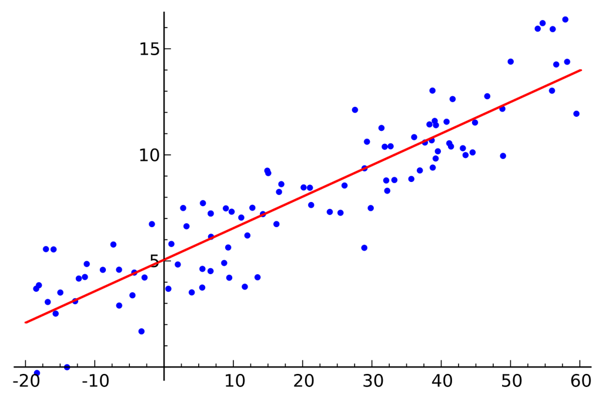

```python
Image("LinearRegressionExample.png")
```

Source: Wikipedia

The red line above is the outcome of the linear regression (the predicted values). The blue dots represent the actual values. This is a simple linear regression as it can be represented in two dimensions (x and y).

### Least Squares

The $\beta_j$ values are estimated by finding a set of $\beta_j$ values that minimize the residual sum of squares (RSS) or mean squared error (MSE). MSE is equal to $\frac{1}{n}RSS$. Error is defined as the difference between the predicted and actual values.

In other words, we need to find $\hat{\beta_0}, \hat{\beta_1},...,\hat{\beta_p}$ that minimizes:

$RSS = \sum_{i=1}^{n} (y_i - (\hat{\beta_0} +\hat{\beta_1}x_{i1}+\hat{\beta_2}x_{i2} + ... +\hat{\beta_p}x_{ip}))^2$

If we take the predicted value as $\hat{y_i} = \hat{\beta_0} +\hat{\beta_1}x_{i1}+\hat{\beta_2}x_{i2} + ... +\hat{\beta_p}x_{ip}$, then this can be rewritten as:

$RSS = \sum_{i=1}^{n} (y_i -\hat{y_i})^2$

which in other words is:

$RSS = \sum_{i=1}^{n} (Error)^2$

It is equally valid to view this as minimizing MSE or as minimizing RMSE (Root Mean Squared Error, which is just the square root of MSE).

## Quality of Linear Regression Model

In a linear regression model, the more explanatory variables you use, the better the fit will be to the training data. So, why not just use all possible explanatory variables?

- This leads to a problem known as overfitting, which is most evident when a model performs well on training data but significantly worse on testing data

To assess the quality of a linear regression model we must consider both RSS (because of the Least Squares Approach) and the number of predictors $p$ used.

This ties into an important concept across all of machine learning known as the **bias-variance tradeoff.**

### Bias-Variance Tradeoff

As bias goes up, variance goes down and vice versa. We can interpret bias and variance as the following:

- Bias: A model's ability to predict the response variable in a training dataset
- Variance: A model's stability of predictions across different training datasets

- The more explanatory variables a model has, the more "flexible" it is.

We aim to find the right balance between the two sides.

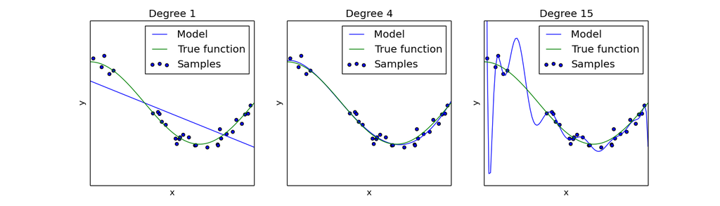

```python
Image("bias-variance-tradeoff.png")
```

Source: scikit-learn.org

- Left: Inflexible Model that is underfit (high bias, low variance), only uses one explanatory variable (hence "Degree 1")
- Middle: Just Right! Uses 4 explanatory variables (hence "Degree 4")
- Right: Flexible Model that is overfit (low bias, high variance), uses 15 explanatory variables (hence "Degree 15")

The two main methods of assessing the quality of a linear regression are **Residual Standard Error (RSE)** and **Adjusted R<sup>2</sup>.** In both of these metrics, the model is penalized for using more predictors.

#### RSE

$RSE = \sqrt{\frac{1}{n-p-1}RSS}$ where $RSS = \sum_{i=1}^{n} (y_i -\hat{y_i})^2$ and $p$ is the number of predictors used.

#### Adjusted R<sup>2</sup>

- $TSS = \sum_{i=1}^{n}(y_i-\bar{y_i})^2$
- $\bar{y_i} = \frac{1}{n}\sum_{i=1}^{n}y_i$

$R^2$ measures the proportion of variability in Y that can be explained by X and ranges from 0 to 1. The closer $R^2$ is to 1, the better.

However, $R^2$ does not factor in the number of predictors and gets "better" as more predictors are added.

This leads to the Adjusted $R^2$ metric. Again, the closer it is to 1, the better.

$R_{adj}^2 = 1-\frac{RSS/(n-p-1)}{TSS/(n-1)}$

## Hypothesis Tests

How can we prove that there is a relationship between response and predictor variables?

- Another way to phrase this is, how can we show that $\hat{\beta_0},...,\hat{\beta_p}$ are significant?

Consider the case where we have a high $R_{adj}^2$ (which is good!), and there are eight $\beta$ coefficients involved. We want to know if we can remove any of those associated predictors without sacrificing too much performance. We could:

- Try all combinations of removing just one of the eight coefficients and see how the metric changes (not efficient)
- Run a hypothesis test to see how significant the $\beta$ values are and remove the insignificant ones (efficient, and demonstrates statistical knowledge!)

A hypothesis test is a way to test if the results of a model or experiment are significant. Essentially, you are testing to what extent your results could have happened just by chance.

- In the case for linear regression, maybe you just got lucky with the set of training data selected!

There are many kinds of hypothesis tests. They always have the following two components:

- **Null Hypothesis** $H_0$: There is no significance
- **Alternative Hypothesis** $H_\alpha$: There is significance

In the context of a model with several $\beta$ values, the hypotheses are:

- $H_0: \beta_1 = \beta_2 = ... = \beta_p = 0$ (there is no relationship between predictor and response variables)
- $H_\alpha:$ at least one of $\beta_j$ is non-zero (there is a relationship between predictor and response variables)

Note that we omit $\beta_0$ in the above as $\beta_0$ is not attached to any predictor variable.

For a single $\beta$ coefficient, the hypotheses are:

- $H_0: \beta_j = 0$
- $H_\alpha: \beta_j$ is non-zero

The most popular method of assessing a hypothesis test is based on the **p-value** which describes the probability that a result occured by chance (therefore we want a small p-value). The general rule of thumb is:

- If the p-value $\leq 0.05$, then the result is significant and we reject the null hypothesis
- Else, the result is not significant and we accept the null hypothesis

Another method for evaluating the significance of a linear regression model is the F-statistic, defined as:

- $F = \frac{(TSS-RSS)/p}{RSS/(n-p-1)}$
- A **large** F-statistic is reason to reject the null hypothesis

## Potential Problems in Linear Regression

There are six main ones.

1. Outliers
2. High-leverage points
3. Collinearity
4. Correlation of residuals
5. Non-linearity in the residuals
6. Non-constant variance in the residuals

Residual is another term for error in regression -- it is the distance between a data point and the regression line.

- Residuals should be random (hence why the last three points above relate to residuals)
- If there is a pattern in the residuals, then there is something missing or off about the model

### Outliers

An outlier is when a $\hat{y_i}$ prediction is unusually far from the observation $y_i$, and can skew the RSS and MSE. This indicates two possibilities:

- (More common) Inaccurate data collection -- in which case just remove or fix the data
- (However!) Some outliers may be true data points that require consideration in the model

A small story about the latter bullet point -- today it is known that air bubbles in drilled ice cores can provide evidence of climate change. However, at first the abnormal amounts of air bubbles in ice cores were ignored as outliers, delaying critical discussions about climate change.

What does "unsually far" mean?

- It depends on the domain
- However, one estimate of defining an outlier is as a point which falls more than 1.5 times the interquartile range above the third quartile or below the first quartile

### High-leverage points

A high-leverage point is when an $x_i$ value takes on an unusual value (e.x. way outside of the usual range), and can skew the RSS and MSE. Same two possibilities as outliers.

### Collinearity

This occurs when explanatory variables are highly correlated with one another. If two explanatory variables are highly correlated, then including both is redundant. This can help us reduce the number of explanatory variables without sacrificing performance (think back to the bias-variance tradeoff!)

### Correlation of residuals

Usually means a time-dependent variable is missing.

### Non-linearity in residuals

Most likely missing an important non-linear explanatory variable.

### Non-constant variance in residuals

This is also known as heteroscedasticity. Most likely need to transform the the dependent variable.

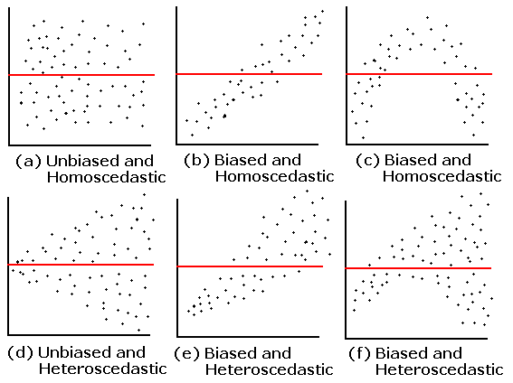

```python
Image('residual_graphs.png')
```

The above is from DePaul University. The ideal residual plot is (a) -- unbiased and homoscedastic (which is the opposite of heteroscedastic).

## More Resources

[Time Series in Regressions](https://www.sas.upenn.edu/~fdiebold/Teaching104/Ch14_slides.pdf)

[Heteroesdasticity in Regression Analysis](https://statisticsbyjim.com/regression/heteroscedasticity-regression/)

[Collinearity](https://stattrek.com/multiple-regression/multicollinearity.aspx)

[Outliers vs. High Leverage Points](https://online.stat.psu.edu/stat462/node/170/)